# Heavy-tailed Gompertz Models with Stan

Sean Anderson

Let’s fit a Gompertz model with heavy-tailed process error to a time series of grey heron counts from England. This is population ID 20579 from the Global Population Dynamics Database.

(Data from Brooks, B., Traill, L. W., Bradshaw, C. J. A. 2006 Minimum viable population sizes and global extinction risk are unrelated. Ecology Letters, 9 (4), 375-382.)

We’ll start by loading some packages and setting some options:

```r
knitr::opts_knit$set(root.dir = "..")
library(rstan)
library(bayesplot)
rstan_options(auto_write = TRUE)
options(mc.cores = parallel::detectCores())
library(ggplot2)
theme_set(theme_light())
```

Let’s read in the data:

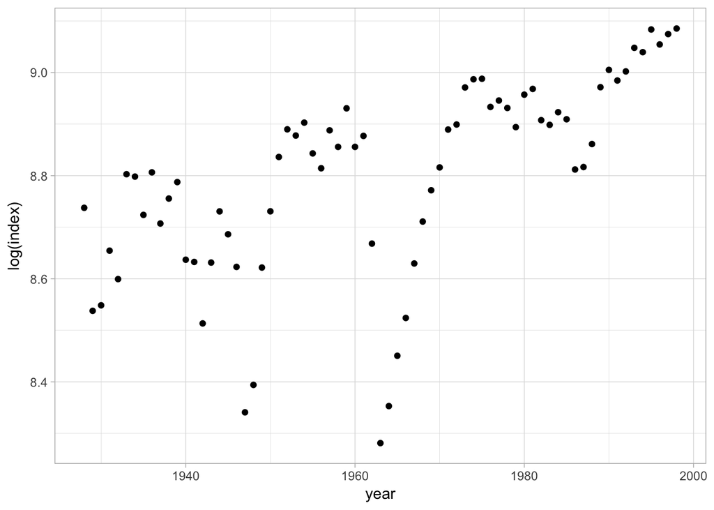

```r
d <- read.csv("data/grey-heron.csv")[,2:3]
# d <- read.csv("data/wind-speed.csv")
names(d) <- c("year", "index")
ggplot(d, aes(year, log(index))) +
  geom_point()
```

You can see the basic model we will work with in the file `R/stan/gompertz.stan`.

We can fit that model with Stan:

```r
m <- stan("R/stan/gompertz.stan",
  data = list(N = nrow(d), y = log(d$index), nu_rate = 0.01),
  iter = 800)
```

Let’s look at the parameters from our model:

```r
pars <- c("lambda", "b", "sigma_proc", "nu")
print(m, pars = pars)
```

```
## Inference for Stan model: gompertz.
## 4 chains, each with iter=800; warmup=400; thin=1;
## post-warmup draws per chain=400, total post-warmup draws=1600.
##
##            mean se_mean   sd 2.5%  25%  50%  75% 97.5% n_eff Rhat
## lambda     1.28    0.02 0.40 0.52 1.01 1.28 1.55  2.12   349 1.01
## b          0.86    0.00 0.04 0.76 0.83 0.86 0.89  0.94   349 1.01
## sigma_proc 0.06    0.00 0.01 0.04 0.05 0.06 0.06  0.08   593 1.00
## nu         3.95    0.21 5.40 2.05 2.51 3.11 4.08  8.69   649 1.00
##
## Samples were drawn using NUTS(diag_e) at Tue Sep  5 09:26:08 2017.
## For each parameter, n_eff is a crude measure of effective sample size,
## and Rhat is the potential scale reduction factor on split chains (at
## convergence, Rhat=1).
```

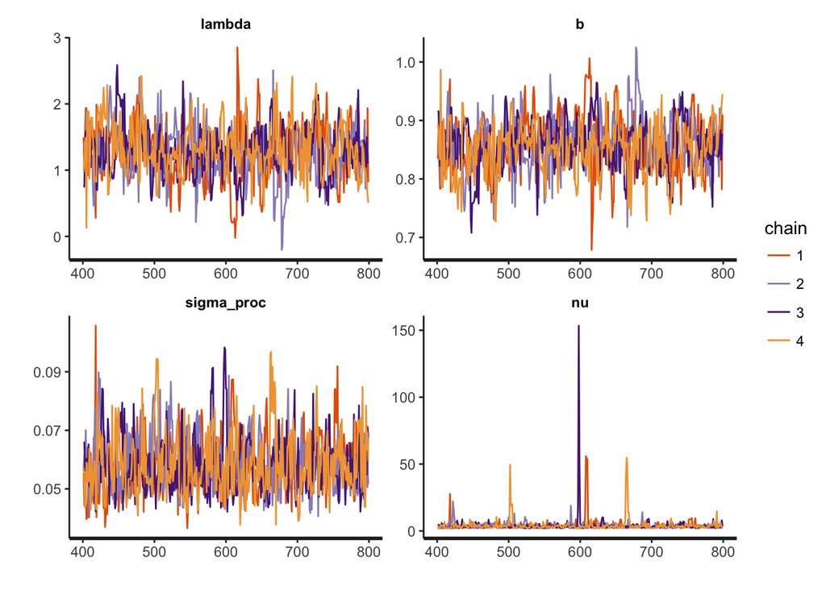

```r
traceplot(m, pars = pars)
```

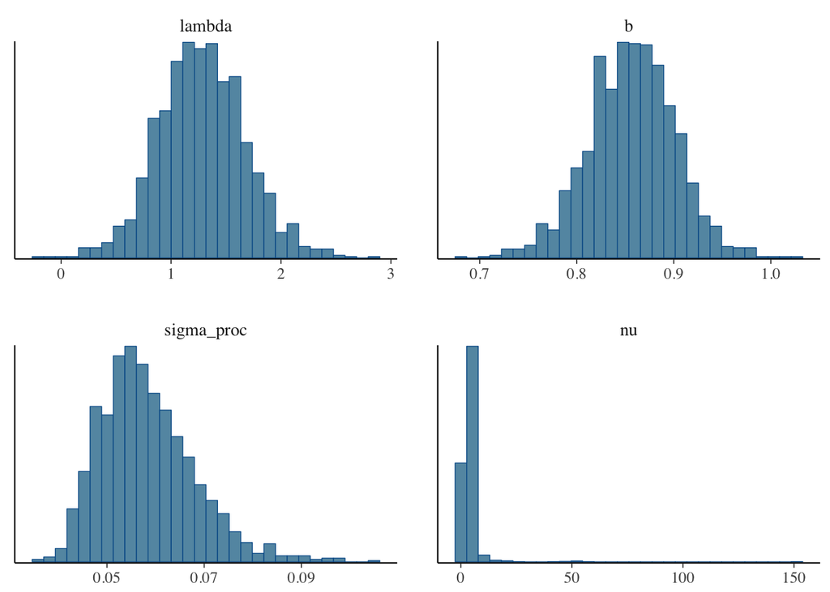

```r
mcmc_hist(as.matrix(m), pars = pars)
```

```r
# mcmc_areas(as.matrix(m), pars = pars)
# shinystan::launch_shinystan(m)
```

We can extract the posterior samples with the function `rstan::extract()`. Part of the Stan code calculated predictions from our model. Alternatively, we could calculate them in R ourselves. We will also calculate residuals from our model.

```r
e <- extract(m)
pred <- data.frame(
  est = apply(e$pred, 2, median),
  l = apply(e$pred, 2, quantile, probs = 0.025),
  h = apply(e$pred, 2, quantile, probs = 0.975),
  year = d$year)
pred$resid <- log(d$index) - pred$est
thresh <- qnorm(0.0001, 0, sd = median(e$sigma_proc))
```

Let’s plot our predictions with the data overlaid:

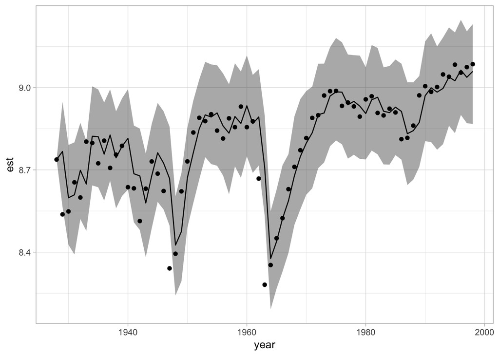

```r
ggplot(pred, aes(year, est, ymin = l, ymax = h)) +
  geom_ribbon(alpha = 0.4) +
  geom_line() +
  geom_point(aes(y = log(d$index)))
```

And we can look at which residuals exceed some arbitrary threshold:

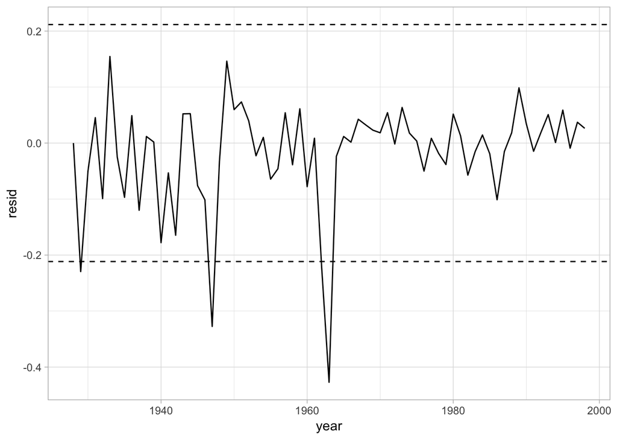

```r
ggplot(pred, aes(year, resid)) +
  geom_line() +
  geom_hline(yintercept = c(thresh, -thresh), lty = 2)
```

As a comparison, we could fit the model with normally distributed process error. We can compare the models with the leave-one-out information criterion (LOOIC).

Also notice that the parameter estimates differ.

```r
m2 <- stan("R/stan/gompertz-normal.stan",
  data = list(N = nrow(d), y = log(d$index)),
  iter = 800)
```

```r
print(m, pars = c("lambda", "b", "sigma_proc", "nu"))
```

```
## Inference for Stan model: gompertz.
## 4 chains, each with iter=800; warmup=400; thin=1;
## post-warmup draws per chain=400, total post-warmup draws=1600.
##
##            mean se_mean   sd 2.5%  25%  50%  75% 97.5% n_eff Rhat
## lambda     1.28    0.02 0.40 0.52 1.01 1.28 1.55  2.12   349 1.01
## b          0.86    0.00 0.04 0.76 0.83 0.86 0.89  0.94   349 1.01
## sigma_proc 0.06    0.00 0.01 0.04 0.05 0.06 0.06  0.08   593 1.00
## nu         3.95    0.21 5.40 2.05 2.51 3.11 4.08  8.69   649 1.00
##
## Samples were drawn using NUTS(diag_e) at Tue Sep  5 09:26:08 2017.
## For each parameter, n_eff is a crude measure of effective sample size,
## and Rhat is the potential scale reduction factor on split chains (at
## convergence, Rhat=1).
```

```r
print(m2, pars = c("lambda", "b", "sigma_proc"))
```

```
## Inference for Stan model: gompertz-normal.
## 4 chains, each with iter=800; warmup=400; thin=1;
## post-warmup draws per chain=400, total post-warmup draws=1600.
##
##            mean se_mean   sd  2.5%  25%  50%  75% 97.5% n_eff Rhat
## lambda     1.09    0.03 0.58 -0.02 0.72 1.07 1.44  2.35   343 1.01
## b          0.88    0.00 0.07  0.73 0.84 0.88 0.92  1.00   344 1.01
## sigma_proc 0.10    0.00 0.01  0.08 0.09 0.10 0.10  0.12   603 1.01
##
## Samples were drawn using NUTS(diag_e) at Tue Sep  5 09:26:18 2017.
## For each parameter, n_eff is a crude measure of effective sample size,
## and Rhat is the potential scale reduction factor on split chains (at
## convergence, Rhat=1).
```

```r
library(loo)
loo(extract_log_lik(m))
```

```
## Computed from 1600 by 70 log-likelihood matrix
##
##          Estimate   SE
## elpd_loo     66.5  9.8
## p_loo         2.0  0.5
## looic      -133.1 19.7
##
## Pareto k diagnostic values:
##                          Count  Pct
## (-Inf, 0.5]   (good)     69    98.6%
##  (0.5, 0.7]   (ok)        1     1.4%
##    (0.7, 1]   (bad)       0     0.0%
##    (1, Inf)   (very bad)  0     0.0%
##
## All Pareto k estimates are ok (k < 0.7)
## See help('pareto-k-diagnostic') for details.
```

```r
loo(extract_log_lik(m2))
```

```
## Computed from 1600 by 70 log-likelihood matrix
##
##          Estimate   SE
## elpd_loo     61.8 10.4
## p_loo         2.6  1.6
## looic      -123.7 20.8
##
## All Pareto k estimates are good (k < 0.5)
## See help('pareto-k-diagnostic') for details.
```

Let’s try fitting our model to a second data set where there aren’t extremes. This time we will use a data set of population counts for house wrens in the mid 20th century in Illinois, USA. GPDD population ID 28.

(Data reference: Kendeigh, S.C. 1982 Bird populations in east central Illinois: fluctuations, variation and development over a half-century. Illinois Biological Monographs, 52:1-136)

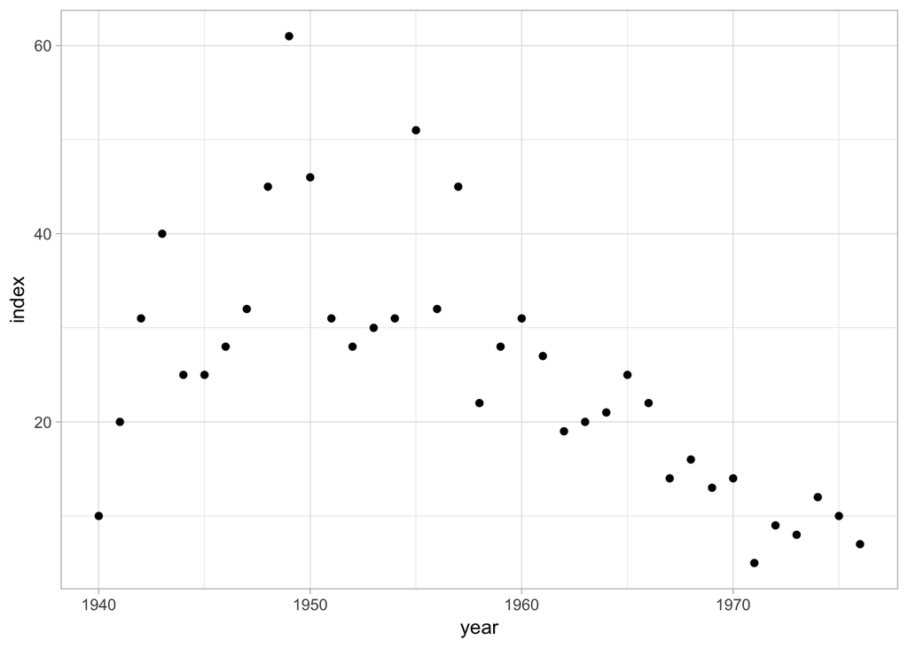

```r
d_hw <- read.csv("data/house-wren.csv")[,2:3]
names(d_hw) <- c("year", "index")
ggplot(d_hw, aes(year, index)) +
  geom_point()
```

```r
m_hw <- stan("R/stan/gompertz.stan",
  data = list(N = nrow(d_hw), y = log(d_hw$index), nu_rate = 0.01),
  iter = 800)
```

```r
print(m_hw, pars = pars)
```

```
## Inference for Stan model: gompertz.
## 4 chains, each with iter=800; warmup=400; thin=1;
## post-warmup draws per chain=400, total post-warmup draws=1600.
##
##             mean se_mean    sd  2.5%   25%   50%    75%  97.5% n_eff Rhat
## lambda      0.60    0.01  0.36 -0.09  0.36  0.59   0.84   1.32   574 1.01
## b           0.81    0.00  0.11  0.58  0.73  0.81   0.88   1.02   566 1.01
## sigma_proc  0.36    0.00  0.05  0.27  0.33  0.35   0.39   0.47   610 1.00
## nu         95.66    2.71 91.29  5.14 27.02 67.32 133.57 348.18  1136 1.00
##
## Samples were drawn using NUTS(diag_e) at Tue Sep  5 09:26:25 2017.
## For each parameter, n_eff is a crude measure of effective sample size,
## and Rhat is the potential scale reduction factor on split chains (at
## convergence, Rhat=1).
```

So in this case our estimate of nu (the degrees of freedom parameter) is much higher. In fact, it approximately matches the prior because the data are not informative about heavy tails. In this case it reverts to be effectively normal:

```r
prior <- rexp(1e6, rate = 0.01)
prior <- prior[prior > 2]
hist(prior)
median(prior)
```

```
## [1] 71.28145
```

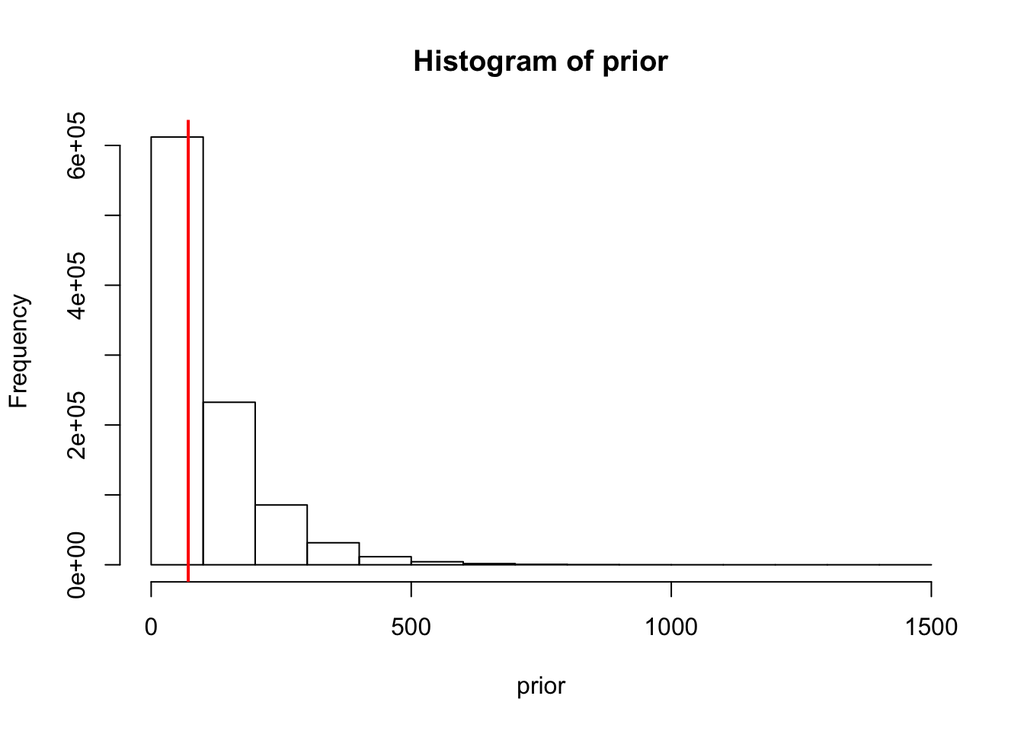

```r
abline(v = median(prior), col = "red", lwd = 2)
```

This choice of prior is based on Fernandez C, Steel MFJ (1998) On Bayesian modeling of fat tails and skewness. J. Am. Stat. Assoc. 93(441):359–371.

Since our models are fit in a Bayesian framework, one useful value to calculate might be the probability density below some threshold value for the degrees of freedom parameter. For example:

```r
nu <- extract(m, pars = "nu")[[1]]
nu_hw <- extract(m_hw, pars = "nu")[[1]]

sum(nu < 10)/length(nu) # or mean(nu < 10)
```

```
## [1] 0.981875
```

```r
sum(nu_hw < 10)/length(nu)
```

```
## [1] 0.079375
```

We’ve often used a value of 10 as a threshold since nu values much above 10 render distributions that are almost indistinguishable from the normal.

In the first case nu is less than 10 with 0.981875 probability. In the second case, there is only about a 0.079375 probability of nu < 10. Remember that even with the prior, there is some probability that nu < 10.

```r
mean(prior < 10)
```

```
## [1] 0.07701475
```

An alternative prior, that we have used in our more recent work is `gamma(shape = 2, rate = 0.1)` as recommended in Juarez, M. A. and M. F. J. Steel. 2010. Model-based clustering of non-Gaussian panel data based on skew-t distributions. J. Bus. Econ. Stat., 28:52–66.

Let’s try a state-space version:

```r
m <- stan("R/stan/gompertz-ss.stan",
  data = list(N = nrow(d), y = log(d$index), nu_rate = 0.01, sigma_obs = 0.05),
  iter = 2000, control = list(max_treedepth = 15, adapt_delta = 0.9))

# m <- stan("R/stan/gompertz-ss-est.stan",
#    data = list(N = nrow(d), y = log(d$index), nu_rate = 0.01),
#    iter = 4000, control = list(max_treedepth = 15, adapt_delta = 0.95), chains = 8)
```

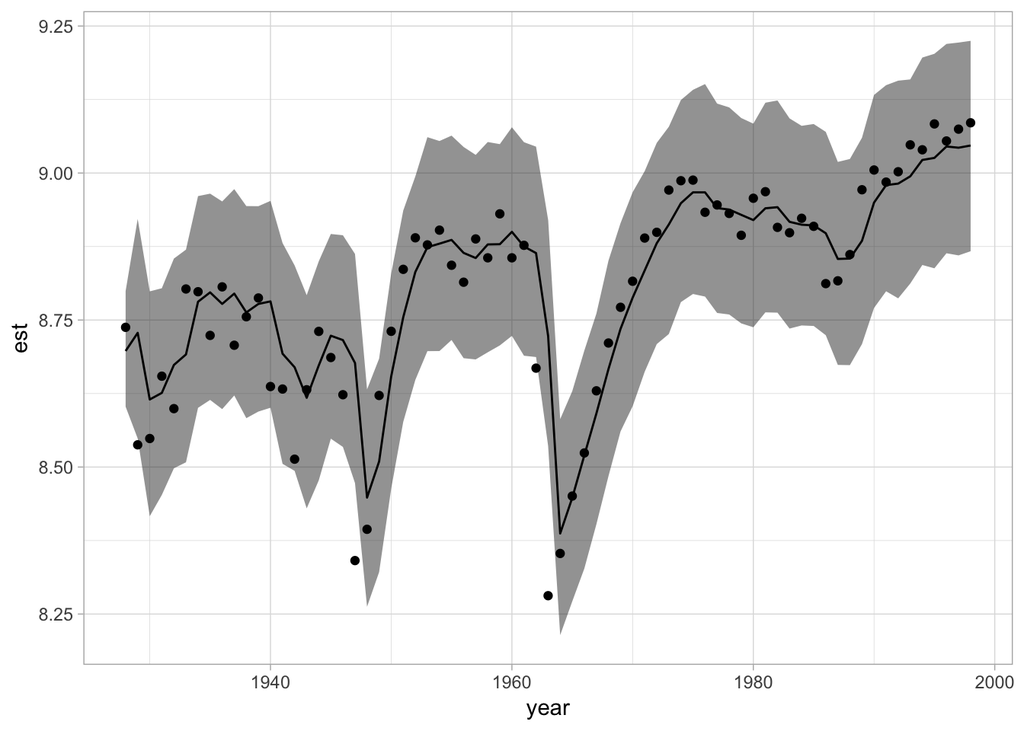

```r
e <- extract(m)
pred <- data.frame(
  est = apply(e$pred, 2, median),
  l = apply(e$pred, 2, quantile, probs = 0.025),
  h = apply(e$pred, 2, quantile, probs = 0.975),
  year = d$year)
ggplot(pred, aes(year, est, ymin = l, ymax = h)) +
  geom_ribbon(alpha = 0.5) +
  geom_line() +
  geom_point(aes(y = log(d$index)))
```

Look at the parameters from our model:

```r
print(m, pars = c("U", "pred", "pred_obs"), include = FALSE)
```

```
## Inference for Stan model: gompertz-ss.
## 4 chains, each with iter=2000; warmup=1000; thin=1;
## post-warmup draws per chain=1000, total post-warmup draws=4000.
##
##             mean se_mean    sd  2.5%   25%   50%   75%  97.5% n_eff Rhat
## lambda      1.24    0.01  0.44  0.34  0.96  1.26  1.53   2.08  2781    1
## b           0.86    0.00  0.05  0.76  0.83  0.86  0.89   0.96  2799    1
## sigma_proc  0.05    0.00  0.01  0.03  0.04  0.05  0.06   0.09  1100    1
## nu          9.32    0.68 32.64  2.05  2.48  3.14  4.63  74.10  2319    1
## lp__       90.61    0.28  8.11 74.31 85.03 90.86 96.30 105.90   834    1
##
## Samples were drawn using NUTS(diag_e) at Tue Sep  5 09:27:13 2017.
## For each parameter, n_eff is a crude measure of effective sample size,
## and Rhat is the potential scale reduction factor on split chains (at
## convergence, Rhat=1).
```

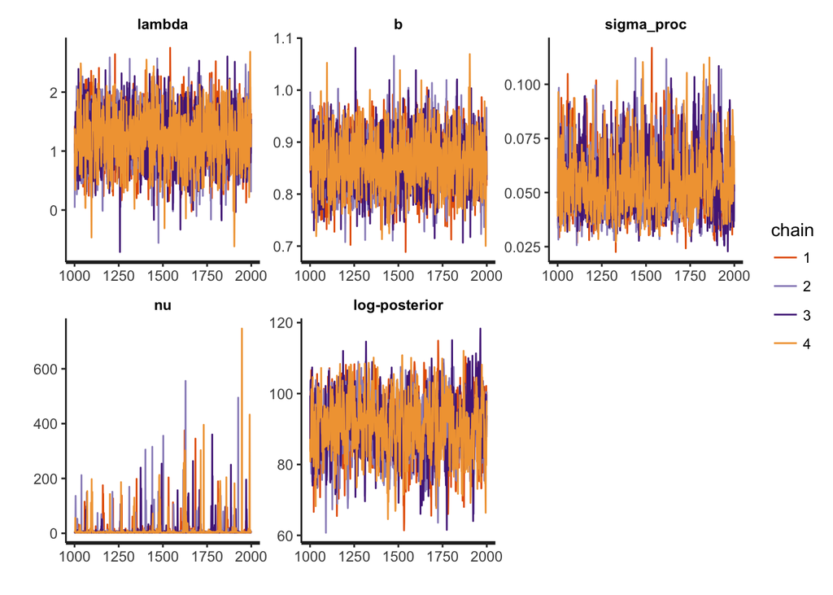

```r
traceplot(m, pars = c("U", "pred", "pred_obs"), include = FALSE)
```

For many other possible heavy-tailed Stan population models, see https://github.com/seananderson/heavy-tails/blob/master/analysis/1-compile-models.R